# Tidyverse in R: Tools for Data Manipulation

Kris Eberwein

February 10, 2017

## Introduction

This walk-through provides a brief introduction to the `dplyr` and `tidyr` packages in R that allow us to reshape our data for visualization or analysis. We will analyse Major League Baseball data from the `Lahaman` package. For convenience, the “base R” equivalents to the `dplyr` and `tidy` functions at bottom of each code block.

### Load the libraries we will need.

```r
library(Lahman)
library(dplyr)
library(tidyr)
library(magrittr)

# NOTE: The dplyr and tidyr packages can be called at one time via the tidyverse package
# library(tidyverse)
```

## Loading Data

R can load data from rational and unstructured databases as well as just about any file format one could imagine. For our use case, we will load an R data package called `Lahman`. This package load Sean Lahman’s baseball database, which is an annual aggregation of statistics for all major league players from 1871 to present.

```r
library(Lahman)
# Load the Batting table from the Lahman database.
batting <- Lahman::Batting
# Take a look at the first few rows of the data set.
head(Batting, 3)
```

```
##    playerID yearID stint teamID lgID  G  AB  R  H X2B X3B HR RBI SB CS BB
## 1 abercda01   1871     1    TRO   NA  1   4  0  0   0   0  0   0  0  0  0
## 2  addybo01   1871     1    RC1   NA 25 118 30 32   6   0  0  13  8  1  4
## 3 allisar01   1871     1    CL1   NA 29 137 28 40   4   5  0  19  3  1  2
##   SO IBB HBP SH SF GIDP
## 1  0  NA  NA NA NA   NA
## 2  0  NA  NA NA NA   NA
## 3  5  NA  NA NA NA   NA
```

## Manipulating Data with dplyr

**GOAL:** Add full player names from the `master` data frame to the `batting` data frame.

The dplyr package has several “join” functions, many of which are similar, in concept, to SQL joins. Full descriptions of dplyr joins can be [found here](http://stat545.com/bit001_dplyr-cheatsheet.html). For our use, a left join is the most appropriate.

```r
# Get Player names and Teams names from other tables
teams <- Lahman::Teams
master <- Lahman::Master
```

```r
library(dplyr)
# Subset master table to only playerID and player names since that's all we need.
master <- select(master, playerID, nameFirst, nameLast)

# Left join master and batting to get the player names in master
battingPlayer <- left_join(batting, master, by = "playerID")

# Base R equivalent:
# master <- master[, c("playerID", "nameFirst", "nameLast")]
# battingPlayer <- merge(x = master, y = batting, by = "playerID", all.x = TRUE)
```

We can use the same strategy as above to add full team names to the data set. **Note** the use of the `rename()` function to rename the ambiguous column “name” to “teamName.”

```r
teamsYr <- select(teams, teamID, yearID, name)
# Rename the team name column to avoid confusion
teamsYr <- rename(teamsYr, "teamName" = name)
batting <- left_join(battingPlayer, teamsYr, by = c("teamID", "yearID"))

# Base R equivalent:
# teamsYr <- teams[, c("teams", "teamID", "yearID", "name")]
# batting <- merge(x = battingPlayer, y = teamsYr, by = c("tea,ID", "yearID"), all.x = TRUE)

head(batting, 3)
```

```
##    playerID yearID stint teamID lgID  G  AB  R  H X2B X3B HR RBI SB CS BB
## 1 abercda01   1871     1    TRO   NA  1   4  0  0   0   0  0   0  0  0  0
## 2  addybo01   1871     1    RC1   NA 25 118 30 32   6   0  0  13  8  1  4
## 3 allisar01   1871     1    CL1   NA 29 137 28 40   4   5  0  19  3  1  2
##   SO IBB HBP SH SF GIDP nameFirst    nameLast               teamName
## 1  0  NA  NA NA NA   NA     Frank Abercrombie         Troy Haymakers
## 2  0  NA  NA NA NA   NA       Bob        Addy  Rockford Forest Citys
## 3  5  NA  NA NA NA   NA       Art     Allison Cleveland Forest Citys
```

## Subseting in dplyr

The `tidyr` package is a compliment to `dplyr` and provides additional data manipulation functions such as “spread” or “gather” data frames. In our case, we’re using the `unite()` function to concatenate the players’ first and last names.

```r
# Player name and team name appear next to playerID and teamID.
batting <- subset(batting, yearID >= 1955 & AB >= 200)

# Concatenate player names with unite() function from tidyr.
library(tidyr)
batting <- unite(batting, playerName, nameFirst, nameLast, sep=" ")

# Base R equivalent:
# batting <- subset(batting, yearID >= 1920 & AB >= 200)
# batting <- transform(batting, playerName = paste0(nameFirst, " ", nameLast))

head(batting, 3)
```

```
##        playerID yearID stint teamID lgID   G  AB   R   H X2B X3B HR RBI SB
## 37450 aaronha01   1955     1    ML1   NL 153 602 105 189  37   9 27 106  3
## 37453 abramca01   1955     1    BAL   AL 118 309  56  75  12   3  6  32  2
## 37456 adcocjo01   1955     1    ML1   NL  84 288  40  76  14   0 15  45  0
##       CS BB SO IBB HBP SH SF GIDP playerName          teamName
## 37450  1 49 61   5   3  7  4   20 Hank Aaron  Milwaukee Braves
## 37453  8 89 69   2   3  3  3    6 Cal Abrams Baltimore Orioles
## 37456  2 31 44   3   2  2  1   13 Joe Adcock  Milwaukee Braves
```

## Using pipes in R

Pipes aren’t native to R, many packages make use of the `magrittr` package, which adds a `%>%` operator as a pipe. The code block below accomplishes everything we have done with the Lahman data set above with fewer lines of code. Note, that only functions can be piped with the `magrittr` package.

```r
batting <- Lahman::Batting
batting <- left_join(batting, master, by = "playerID") %>%
    subset(yearID >= 1955 & AB >= 200) %>%
    left_join(teams[,c("teamID", "yearID", "name")], by = c("teamID", "yearID")) %>%
    unite(playerName, nameFirst, nameLast, sep=" ") %>% rename(teamName = name)

# Base R equivalent:
# batting <- Lahmand::Batting
# batting <- merge(x = master, y = batting, by = "playerID", all.x = TRUE)
# batting <- subset(batting, yearID >= 1955 & AB >= 200)
# batting <- transform(batting, name = paste0(nameFirst, " ", nameLast))
# batting <- merge(x = master, y = batting, by = c("tea,ID", "yearID"), all.x = TRUE)
# colnames(batting) <- c("playerID", "yearID", "stint", "teamID", "lgID", "G", "AB", "R",
# "H", "X2B", "X3B", "HR", "RBI", "SB", "CS", "BB", "SO", "IBB", "HBP", "SH", "SF", "GIDP", "playerName",
# "teamName")

head(batting, 3)
```

```
##    playerID yearID stint teamID lgID   G  AB   R   H X2B X3B HR RBI SB CS
## 1 aaronha01   1955     1    ML1   NL 153 602 105 189  37   9 27 106  3  1
## 2 abramca01   1955     1    BAL   AL 118 309  56  75  12   3  6  32  2  8
## 3 adcocjo01   1955     1    ML1   NL  84 288  40  76  14   0 15  45  0  2
##   BB SO IBB HBP SH SF GIDP playerName          teamName
## 1 49 61   5   3  7  4   20 Hank Aaron  Milwaukee Braves
## 2 89 69   2   3  3  3    6 Cal Abrams Baltimore Orioles
## 3 31 44   3   2  2  1   13 Joe Adcock  Milwaukee Braves
```

The forward pipe operator is exported by `dplyr`, `tidyr`, and several over R packages. However, the `magrittr` package, which is the basis for the pipe, provides additional operations. For example, with the `%<>%` operator, we can make a data frame the source *and* the target of a transformation. For example, the following statements accomplish the same task.

```r
batting <- subset(batting, yearID >= 1900)

# ...is the same as
batting %<>% subset(yearID >= 1900)
```

## Calculations and Mutation

**GOAL:** Add two new columns to our data frame `BA` and `OPS`, which calculate batting average and on-base percentage plus slugging percentage. Both calculations can be done as one line of code.

```r
# This becomes a one-liner with the use of the mutate function and a pipe.
batting %<>% mutate(BA = H/AB)

# Multimple calculations can be passed to one mutae command.
batting %<>% mutate(BA = H/AB, OPS = (H+BB+IBB+HBP)/(AB+BB+IBB+HBP+SF+SH)+((H+2*X2B+3*X3B+4*HR)/AB))

# Base R equivalent:
# batting$BA <- batting$H / batting$AB
# batting$OPS <- ((batting$H + batting$BB + batting$IBB + batting$HBP) /
# (batting$AB + batting$BB + batting$IBB + batting$HBP + batting$SF + batting$SH) +
# (batting$H + 2 * batting$X2B + 3 * batting$X3B + 4 * batting$HR) / batting$AB)

head(batting, 3)
```

```
##    playerID yearID stint teamID lgID   G  AB   R   H X2B X3B HR RBI SB CS
## 1 aaronha01   1955     1    ML1   NL 153 602 105 189  37   9 27 106  3  1
## 2 abramca01   1955     1    BAL   AL 118 309  56  75  12   3  6  32  2  8
## 3 adcocjo01   1955     1    ML1   NL  84 288  40  76  14   0 15  45  0  2
##   BB SO IBB HBP SH SF GIDP playerName          teamName        BA
## 1 49 61   5   3  7  4   20 Hank Aaron  Milwaukee Braves 0.3139535
## 2 89 69   2   3  3  3    6 Cal Abrams Baltimore Orioles 0.2427184
## 3 31 44   3   2  2  1   13 Joe Adcock  Milwaukee Braves 0.2638889
##         OPS
## 1 1.0282937
## 2 0.8403874
## 3 0.9119521
```

## Grouping and Aggregating

**GOAL:** The batting data frame is grouped by player and year. Find the total career home runs for every player in the data frame.

Like joins, grouping and aggregating adhere to concepts found in SQL. The data frame is grouped by player and year, so we’ll use the `group_by()` function to group by playerID only and then the `summarise()` function to find the sum of HR grouped by player.

*If we did it right, we should see Barry Bonds and Hank Aaron at the top of the list.*

```r
batting <- Lahman::Batting
# Grouped calculations
moonShot <- group_by(batting, playerID) %>% summarise(careerHR = sum(HR)) %>% arrange(desc(careerHR))

# Base R equivalent:
# moonShot <- batting
# moonShot <- aggregate(moonShot$HR, by = list(moonShot$playerID), FUN=sum)
# colnames(moonShot) <- c("playerID", "careerHR")
# moonShot <- moonShot[order(-moonShot$careerHR),]

head(moonShot, 3)
```

```
## # A tibble: 3 x 2
##    playerID careerHR
##       <chr>    <int>
## 1 bondsba01      762
## 2 aaronha01      755
## 3  ruthba01      714
```

## Spreading Data with tidyr

The `tidyr` package picks up where `dplyr` ends. Some of the most useful functions of the package are `spread()` and `gather()`, which allows us to recast our data frame in “wide” or “long” formats. The ability to switch data from wide to long formats can be helpful when preforming multiple analysis on a single data set.

Set the batting table “wide” with a column for each year using the `spread()` function. This would be particularly helpful if plotting or visualizing the data.

```r
batting <- Lahman::Batting

BattingLong <- batting %>% filter(yearID >= 2000 & AB >=200) %>% group_by(playerID, yearID) %>% summarize(HR = sum(HR))

BattingWide <- spread(BattingLong, key=yearID, value=HR)

# names <- BattingLong$yearID
# BattingWide <- as.data.frame(t(BattingLong[,-2]))
# colnames(BattingWide) <- names
# BattingWide$playerID <- factor(row.names(BattingWide))

head(BattingWide, 3)
```

```
## # A tibble: 3 x 18
## # Groups:   playerID [3]
##    playerID `2000` `2001` `2002` `2003` `2004` `2005` `2006` `2007` `2008`
##       <chr>  <int>  <int>  <int>  <int>  <int>  <int>  <int>  <int>  <int>
## 1 abbotje01      3     NA     NA     NA     NA     NA     NA     NA     NA
## 2 abercre01     NA     NA     NA     NA     NA     NA      5     NA     NA
## 3 abernbr01     NA      5      2     NA     NA     NA     NA     NA     NA
## # ... with 8 more variables: `2009` <int>, `2010` <int>, `2011` <int>,
## #   `2012` <int>, `2013` <int>, `2014` <int>, `2015` <int>, `2016` <int>
```

Use the `gather()` function to take the same data and cast it to “long” with two columns; a key and a value.

```r
BattingGathered <- gather(batting)
head(BattingGathered, 10)
```

```
##         key     value
## 1  playerID abercda01
## 2  playerID  addybo01
## 3  playerID allisar01
## 4  playerID allisdo01
## 5  playerID ansonca01
## 6  playerID armstbo01
## 7  playerID barkeal01
## 8  playerID barnero01
## 9  playerID barrebi01
## 10 playerID barrofr01
```

## Visualization

The default visualization in the R language is the `plot()` function from base R. However, the `ggplot2` package has become somewhat of a defacto standard.

```r
batting <- Lahman::Batting

# Subset for players who had at least one at-bat, group by year, aggregate, and calculate a league batting average.
# Use summarize function in case of multiple sints.
batting %<>% subset(AB >= 200 & yearID >= 1920) %>% group_by(yearID, playerID) %>%
    summarise(H = sum(H), AB = sum(AB), R = sum(R)) %>% mutate(BA = H/AB)
```

The `ggplot2` package can has tons of options, which can be overwhelming at first. However, it is quite simple in basic usage. **Note:** The `+` operator in this package acts the same as the standard pipe operator `%>%` from the `magrittr` package.

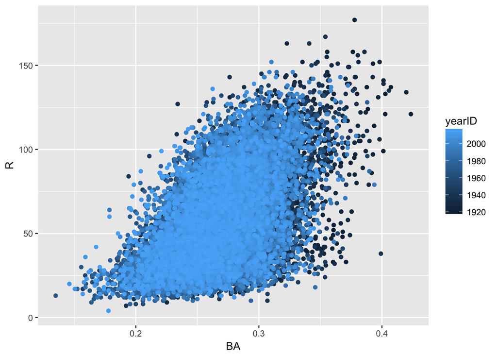

```r
library(ggplot2)
ggplot(batting, aes(BA, R)) +
    geom_point(aes(colour = yearID))
```

We can see by the plot that there seems to be a relationship between batting average and runs scored.

## Data Dictionary

### Column definitions from the Lahman Database:

- G = Games played
- AB = At bats
- R = Runs
- H = Hits
- X2B = Doubles
- X3B = Triples
- HR = Home Runs
- BB = Walk / base on balls
- HBP = Hit by pitch
- SF = Sacrifice Fly
- SH = Sacrifice Hit
- Stint = How many times a player was a member of a team in one season. Example, if `Stint=2`, the player was traded to another team, then re-acquired by his first team in the same season.

## R / Python Terminology

Table borrowed from the `reticulate` [documentation](https://github.com/rstudio/reticulate).

| R | Python | Examples |
| --- | --- | --- |
| Single-element vector | Scalar | `1`, `1L`, `TRUE`, `"foo"` |
| Multi-element vector | List | `c(1.0, 2.0, 3.0)`, `c(1L, 2L, 3L)` |
| List of multiple types | Tuple | `list(1L, TRUE, "foo")` |
| Named list | Dict | `list(a = 1L, b = 2.0)`, `dict(x = x_data)` |
| Matrix/Array | NumPy ndarray | `matrix(c(1,2,3,4), nrow = 2, ncol = 2)` |